# Module 10

Dan Miller

2023-11-09

```r
library(spdep)
library(sf)
#install.packages("tidyverse")
library(tidyverse)
#install.packages("tmap")
library(tmap)
#install.packages("spatialreg")
library(spatialreg)
data <- read_sf("data/2004_Election_Counties.shp")
```

```r
data
```

```
## Simple feature collection with 3111 features and 69 fields
## Geometry type: MULTIPOLYGON
## Dimension:     XY
## Bounding box:  xmin: -124.7314 ymin: 24.95597 xmax: -66.96985 ymax: 49.37173
## Geodetic CRS:  GCS_Assumed_Geographic_1
## # A tibble: 3,111 × 70
##    NAME         STATE_NAME STATE_FIPS CNTY_FIPS FIPS   AREA FIPS_num  Bush Kerry
##    <chr>        <chr>      <chr>      <chr>     <chr> <dbl>    <int> <dbl> <dbl>
##  1 Lake of the… Minnesota  27         077       27077 1784.    27077  1428   921
##  2 Ferry        Washington 53         019       53019 2280.    53019  1969  1156
##  3 Stevens      Washington 53         065       53065 2530.    53065 10789  5763
##  4 Okanogan     Washington 53         047       53047 5306.    53047  8336  5511
##  5 Pend Oreille Washington 53         051       53051 1445.    53051  3671  2292
##  6 Boundary     Idaho      16         021       16021 1279.    16021  3012  1268
##  7 Lincoln      Montana    30         053       30053 3746.    30053  5884  2320
##  8 Flathead     Montana    30         029       30029 5232.    30029 25966 11566
##  9 Glacier      Montana    30         035       30035 3124.    30035  1828  2641
## 10 Toole        Montana    30         101       30101 1943.    30101  1582   690
## # ℹ 3,101 more rows
## # ℹ 61 more variables: County_F <dbl>, Nader <dbl>, Total <dbl>,
## #   Bush_pct <dbl>, Kerry_pct <dbl>, Nader_pct <dbl>, MDratio <dbl>,
## #   hosp <dbl>, pcthisp <dbl>, pcturban <dbl>, urbrural <dbl>, pctfemhh <dbl>,
## #   pcincome <dbl>, pctpoor <dbl>, pctlt9ed <dbl>, pcthsed <dbl>,
## #   pctcoled <dbl>, unemploy <dbl>, pctwhtcl <dbl>, homevalu <dbl>, rent <dbl>,
## #   popdens <dbl>, crowded <dbl>, ginirev <dbl>, SmokecurM <dbl>, …
```

### Creating Weights Matrix

```r
W_cont_el <- poly2nb(data, queen=T)
W_cont_el_mat <- nb2listw(W_cont_el, style="W", zero.policy=TRUE)

## Global Autocorrelation Tests: Moran's I
moran.test(data$Bush_pct, listw=W_cont_el_mat, zero.policy=T)
```

```
##
##  Moran I test under randomisation
##
## data:  data$Bush_pct
## weights: W_cont_el_mat  n reduced by no-neighbour observations
##
##
## Moran I statistic standard deviate = 51.731, p-value < 2.2e-16
## alternative hypothesis: greater
## sample estimates:
## Moran I statistic       Expectation          Variance
##      0.5565174275     -0.0003219575      0.0001158676
```

```r
## Global Autocorrelation Tests: Geary's C
geary.test(data$Bush_pct, listw=W_cont_el_mat, zero.policy=T)
```

```
##
##  Geary C test under randomisation
##
## data:  data$Bush_pct
## weights: W_cont_el_mat
##
## Geary C statistic standard deviate = 50.359, p-value < 2.2e-16
## alternative hypothesis: Expectation greater than statistic
## sample estimates:
## Geary C statistic       Expectation          Variance
##      0.4204068521      1.0000000000      0.0001324606
```

```r
## Global Autocorrelation Tests: Moran's I
moran.test(data$pcincome, listw=W_cont_el_mat, zero.policy=T)
```

```
##
##  Moran I test under randomisation
##
## data:  data$pcincome
## weights: W_cont_el_mat  n reduced by no-neighbour observations
##
##
## Moran I statistic standard deviate = 37.895, p-value < 2.2e-16
## alternative hypothesis: greater
## sample estimates:
## Moran I statistic       Expectation          Variance
##      0.4072034801     -0.0003219575      0.0001156483
```

```r
## Global Autocorrelation Tests: Geary's C
geary.test(data$pcincome, listw=W_cont_el_mat, zero.policy=T)
```

```
##
##  Geary C test under randomisation
##
## data:  data$pcincome
## weights: W_cont_el_mat
##
## Geary C statistic standard deviate = 34.924, p-value < 2.2e-16
## alternative hypothesis: Expectation greater than statistic
## sample estimates:
## Geary C statistic       Expectation          Variance
##      0.5446582804      1.0000000000      0.0001699943
```

# Questions:

### Question 1

**Use lm() to estimate Bush_pct ~ pcincome using ordinary linear least square (OLS). Plot the residuals and test for spatial autocorrelation. Provide an example of your map and an output of of your spatial autocorrelation results. Hint your results should look similar to the plot on the right.**

```r
palette <- c("#d7191c","#fdae61","#ffffbf","#a6d96a","#1a9641")
model <- lm(Bush_pct ~ pcincome, data = data)
data$residuals <- model$residuals

data$residuals_range <- cut(
  data$residuals,
  breaks = c(-50, -25, -5, 5, 25, 50),
  labels = c("(-50:-25)", "(-25:-5)", "(-5:5)", "(5:25)", "(25:50)"),
  include.lowest = TRUE
)



tm_shape(data, unit = "mi") +
  tm_polygons(

    # Data variable being filled for chloropleth
    col = "residuals_range",

    # Title / Color palette
    title = "Residuals",
    palette = palette,

    # Number of classes
    n = 5,

    # Method of creating classes (quantile generally preferred)
    style = "quantile") +


  # Adding Scale Bar, Default position is "right","bottom"
   tm_scale_bar(position = c("center", "bottom")) +

  # Adding compass rose
  tm_compass(position = c("right", "bottom"), type = "rose", size = 2) +

  # Final formatting adjustments
  tm_layout(legend.outside = FALSE,
          title = "US Residuals",
          inner.margins = .125,
          legend.frame = TRUE
          )
```

```
## Scale bar set for latitude mi and will be different at the top and bottom of the map.
```

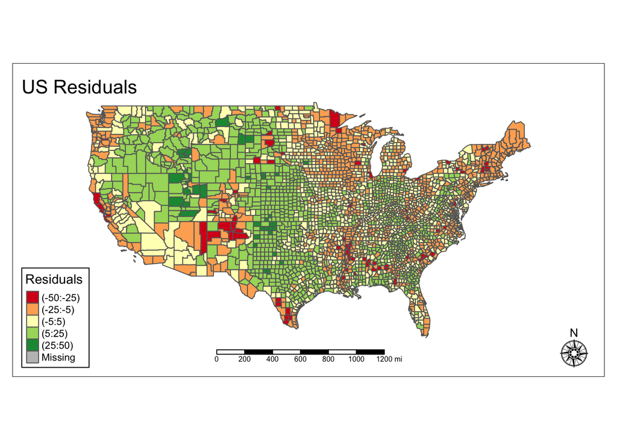

```r
moran.test(model$residuals,  listw=W_cont_el_mat, zero.policy=T )
```

```
##
##  Moran I test under randomisation
##
## data:  model$residuals
## weights: W_cont_el_mat  n reduced by no-neighbour observations
##
##
## Moran I statistic standard deviate = 51.138, p-value < 2.2e-16
## alternative hypothesis: greater
## sample estimates:
## Moran I statistic       Expectation          Variance
##      0.5501302998     -0.0003219575      0.0001158637
```

### Question 2

**2.) Estimate the same relationship as above using the spatial lag model instead. The lag model function is in the spdep library and is called lagsarlm. Provide the results of your regression.**

```r
model_lag <- lagsarlm(Bush_pct ~ pcincome, data = data, listw = W_cont_el_mat, zero.policy = TRUE)
model_lag
```

```
##
## Call:
## lagsarlm(formula = Bush_pct ~ pcincome, data = data, listw = W_cont_el_mat,
##     zero.policy = TRUE)
## Type: lag
##
## Coefficients:
##          rho  (Intercept)     pcincome
## 7.510418e-01 1.407314e+01 5.460041e-05
##
## Log likelihood: -11425.87
```

### Mapping Lag Residuals

```r
data$lag_residuals<- model_lag$residuals
data$lag_residuals_range <- cut(
  data$lag_residuals,
  breaks = c(-50, -25, -5, 5, 25, 50),
  labels = c("(-50:-25)", "(-25:-5)", "(-5:5)", "(5:25)", "(25:50)"),
  include.lowest = TRUE
)



tm_shape(data, unit = "mi") +
  tm_polygons(

    # Data variable being filled for chloropleth
    col = "lag_residuals_range",

    # Title / Color palette
    title = "Lag Residuals",
    palette = palette,

    # Number of classes
    n = 5,

    # Method of creating classes (quantile generally preferred)
    style = "quantile") +

  # Adding Scale Bar, Default position is "right","bottom"
   tm_scale_bar(position = c("center", "bottom")) +

  # Adding compass rose
  tm_compass(position = c("right", "bottom"), type = "rose", size = 2) +

  # Final formatting adjustments
  tm_layout(legend.outside = FALSE,
          title = "US Lag Residuals",
          inner.margins = .125,
          legend.frame = TRUE
          )
```

```
## Scale bar set for latitude mi and will be different at the top and bottom of the map.
```

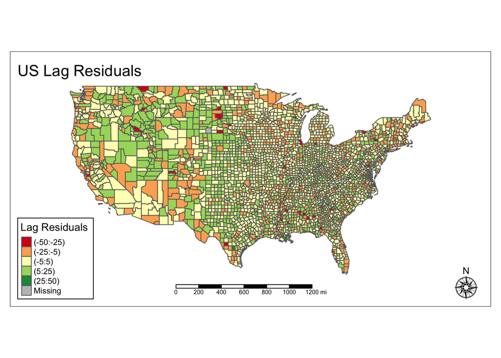

### Question 3

**Perform a Moran’s I test on the residuals of the lag model and report your results. Is there evidence of remaining spatial autocorrelation in the residuals?**

```r
moran.test(model_lag$residuals, listw = W_cont_el_mat, zero.policy = TRUE)
```

```
##
##  Moran I test under randomisation
##
## data:  model_lag$residuals
## weights: W_cont_el_mat  n reduced by no-neighbour observations
##
##
## Moran I statistic standard deviate = -3.7788, p-value = 0.9999
## alternative hypothesis: greater
## sample estimates:
## Moran I statistic       Expectation          Variance
##     -0.0409754776     -0.0003219575      0.0001157390
```

After performing the lag test our resulting Morans I test shows a Moran’s I statistic very close to zero and a p-value higher than all commonly used significance levels, thus we fail to reject our null-hypothesis and conclude there is no significant spatial autocorrelation.

### Question 4

**This time, estimate the same function using the error model (errorsarlm). Provide the results of the error model and explain any differences in the coefficient variable from the lag to the error model. Also perform a Moran’s I test on the residuals of the error model and provide those results.**

```r
model_err <- errorsarlm(Bush_pct ~ pcincome, data = data, listw = W_cont_el_mat, zero.policy = TRUE)
model_err
```

```
##
## Call:
## errorsarlm(formula = Bush_pct ~ pcincome, data = data, listw = W_cont_el_mat,
##     zero.policy = TRUE)
## Type: error
##
## Coefficients:
##       lambda  (Intercept)     pcincome
## 7.619651e-01 5.834719e+01 8.021757e-05
##
## Log likelihood: -11428.06
```

```r
moran.test(model_err$residuals,  listw = W_cont_el_mat, zero.policy = TRUE)
```

```
##
##  Moran I test under randomisation
##
## data:  model_err$residuals
## weights: W_cont_el_mat  n reduced by no-neighbour observations
##
##
## Moran I statistic standard deviate = -4.7192, p-value = 1
## alternative hypothesis: greater
## sample estimates:
## Moran I statistic       Expectation          Variance
##     -0.0510919742     -0.0003219575      0.0001157378
```

```r
data$err_residuals <- model_err$residuals
data$err_residuals_range <- cut(
  data$err_residuals,
  breaks = c(-50, -25, -5, 5, 25, 50),
  labels = c("(-50:-25)", "(-25:-5)", "(-5:5)", "(5:25)", "(25:50)"),
  include.lowest = TRUE
)



tm_shape(data, unit = "mi") +
  tm_polygons(

    # Data variable being filled for chloropleth
    col = "err_residuals_range",

    # Title / Color palette
    title = "Error Residuals",
    palette = palette,

    # Number of classes
    n = 5,

    # Method of creating classes (quantile generally preferred)
    style = "quantile") +

  # Adding Scale Bar, Default position is "right","bottom"
   tm_scale_bar(position = c("center", "bottom")) +

  # Adding compass rose
  tm_compass(position = c("right", "bottom"), type = "rose", size = 2) +

  # Final formatting adjustments
  tm_layout(legend.outside = FALSE,
          title = "US Error Residuals",
          inner.margins = .125,
          legend.frame = TRUE
          )
```

```
## Scale bar set for latitude mi and will be different at the top and bottom of the map.
```

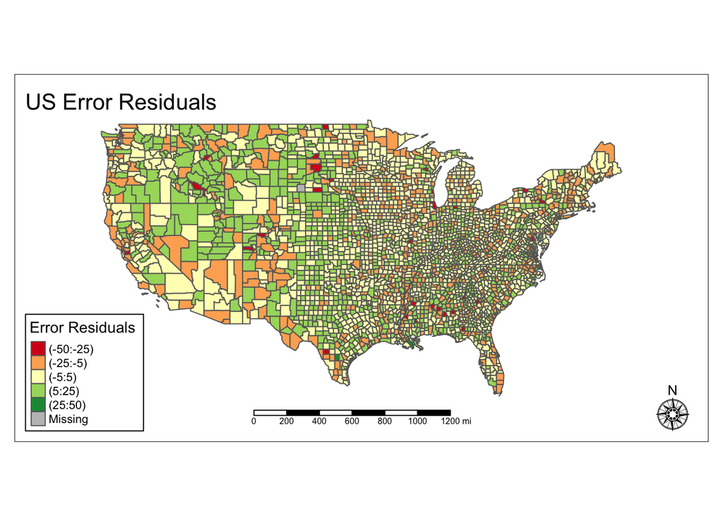

So the moran’s i test for both the lag and error residuals returned very similair values overall (almost identical even). HOwever I do not know/ understand what the differences mean in the coeffecients section. For our error model we recieved the followed readout: Coefficients: lambda (Intercept) pcincome 7.619651e-01 5.834719e+01 8.021757e-05

and for our lag model:

rho (Intercept) pcincome 7.510418e-01 1.407314e+01 5.460041e-05